# CLC

AMP

2024-03-31

From Matt K

The second dataset is the threshold elevation defining the boundary between forest and marsh, aggregated by watershed. This is only for Maryland and Virginia, so won’t work for EXCHANGE sites in DE or NJ. https://portal.edirepository.org/nis/mapbrowse?packageid=knb-lter-vcr.343.2 File #1 contains the watershed names and threshold elevations. File #3 contains the watershed boundaries. You’ll need to identify the watershed that the EXCHANGE site is in, then find the threshold elevation for that watershed before running the regression. Its simpler than it sounds.

I’m sending links rather than the actual files so that you have all the metadata and other potentially useful files handy.

# Vertical Retreat Rates

## Load in Data

#### vertical forest retreat rates from:

Chen, Y. and M.L. Kirwan. 2023. vertical and vertical forest retreat rate in the mid-Atlantic sea-level rise hotspot ver 1. Environmental Data Initiative. https://doi.org/10.6073/pasta/4edf9b0d9d6660d354710748b2cf56f0 (Accessed 2024-03-31).

#### EC 1 data from:

Pennington S C ; Alford S ; Back M P ; Bailey V ; Baldwin A ; Bolinger J ; Bowe M ; Boyanov M I ; Cianci-Gaskill J A ; Conroy N A ; Cooper M J ; Day D ; Demeo A ; Derby K ; Detweiler D ; Devres-Zimmerman S ; Eberhard E ; Gedan K ; Haaf L ; Homolka K K ; Johnson E ; Kemner K M ; Khan A ; Kirwan M ; Kittaka P ; Koontz E ; Langley A ; Leff R ; Lerberg S ; Lewis A M ; Malkin S ; Marcarelli A M ; McMurray S E ; Messerschmidt T ; Michael T C ; Michael H A ; Minor E C ; Moye B ; Mozdzer T J ; Neubauer S ; Norris C G ; O’Loughlin E J ; Otenburg O ; Pain A ; Patel K F ; Philben M ; Phillips E ; Pratt D ; Regier P ; Jr J A R ; Sage L ; Sandborn D ; Smith S ; Smith A ; Soin-Voshell S ; Song B ; Sprague-Getsy A ; Laurent K S ; Staver L ; Stearns A ; Stetten L ; Swerida R ; Theuerkauf E J ; Tully K ; Vargas R ; Ward N D ; Watson E ; Weilminster C ; Myers-Pigg A N (2023): EXCHANGE Campaign 1: A Community-Driven Baseline Characterization of Soils, Sediments, and Water Across Coastal Gradients. COMPASS-FME, ESS-DIVE repository. Dataset. doi:10.15485/1960313 accessed via https://data.ess-dive.lbl.gov/datasets/doi:10.15485/1960313 on 2024-03-31

Projected Coordinate Reference System (CRS) “WGS 84 / UTM zone 18N” = EPSG code for this CRS is 32618.

# Analysis time!

vertical retreat rate (m year−1)

```
## Correlation computed with
## • Method: 'pearson'
## • Missing treated using: 'pairwise.complete.obs'
```

```
## # A tibble: 9 × 2
##   term                            V_RetreatR
##   <chr>                                <dbl>
## 1 bulk_density_g_cm3                0.0613
## 2 specific_conductance_us_cm       -0.339
## 3 moisturecontent_perc_drywtbasis  -0.390
## 4 ph                                0.000878
## 5 carbon_weight_perc               -0.110
## 6 nitrogen_weight_perc             -0.0583
## 7 latitude                         -0.203
## 8 longitude                         0.145
## 9 elevation_m                       0.0848
```

```
##
## Call:
## lm(formula = V_RetreatR ~ ., data = clc_data_num)
##
## Residuals:
##     Min      1Q  Median      3Q     Max
## -3.4422 -0.7145 -0.1916  0.6048  3.1306
##
## Coefficients:
##                                   Estimate Std. Error t value Pr(>|t|)
## (Intercept)                      4.667e+02  1.966e+02   2.374   0.0552 .
## bulk_density_g_cm3              -7.633e-02  3.882e+00  -0.020   0.9849
## specific_conductance_us_cm      -5.653e-04  3.948e-04  -1.432   0.2022
## moisturecontent_perc_drywtbasis -8.592e-03  8.600e-03  -0.999   0.3563
## ph                              -1.243e+00  1.731e+00  -0.718   0.4997
## carbon_weight_perc              -6.180e-02  3.591e-01  -0.172   0.8690
## nitrogen_weight_perc             6.649e+00  4.929e+00   1.349   0.2261
## latitude                        -3.005e+00  1.423e+00  -2.112   0.0792 .
## longitude                        4.479e+00  2.185e+00   2.050   0.0862 .
## elevation_m                     -8.846e-01  1.931e+00  -0.458   0.6630
## ---
## Signif. codes:  0 '***' 0.001 '**' 0.01 '*' 0.05 '.' 0.1 ' ' 1
##
## Residual standard error: 2.672 on 6 degrees of freedom
##   (4 observations deleted due to missingness)
## Multiple R-squared:  0.7749, Adjusted R-squared:  0.4372
## F-statistic: 2.295 on 9 and 6 DF,  p-value: 0.1621
```

```
## Correlation computed with
## • Method: 'spearman'
## • Missing treated using: 'pairwise.complete.obs'
```

```
## # A tibble: 9 × 2
##   term                            V_RetreatR
##   <chr>                                <dbl>
## 1 bulk_density_g_cm3                  0.252
## 2 specific_conductance_us_cm         -0.375
## 3 moisturecontent_perc_drywtbasis    -0.436
## 4 ph                                  0.107
## 5 carbon_weight_perc                 -0.179
## 6 nitrogen_weight_perc               -0.195
## 7 latitude                           -0.113
## 8 longitude                           0.182
## 9 elevation_m                         0.0707
```

Looking maybe promising? Need significance values though…

```
## [1] Variable        correlation.cor p.value
## <0 rows> (or 0-length row.names)
```

nope…dang

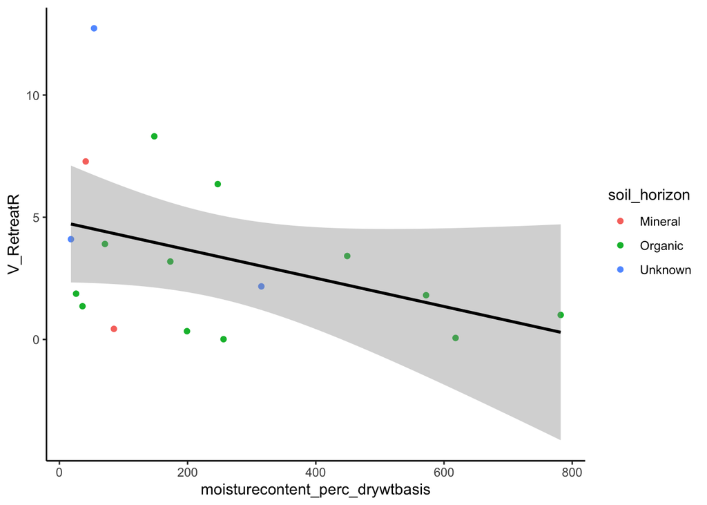

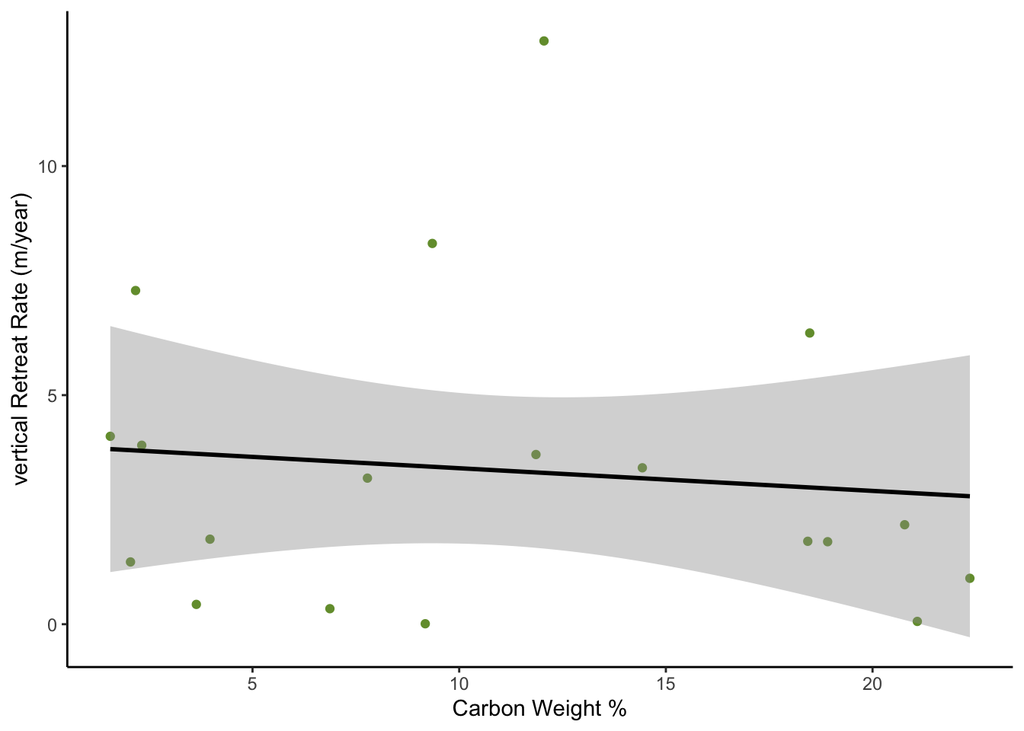

Hmm, wondering if I have enough data to try random forest? Probably not going to work, messing around with it anyway…

messing around some more…

# Make a map

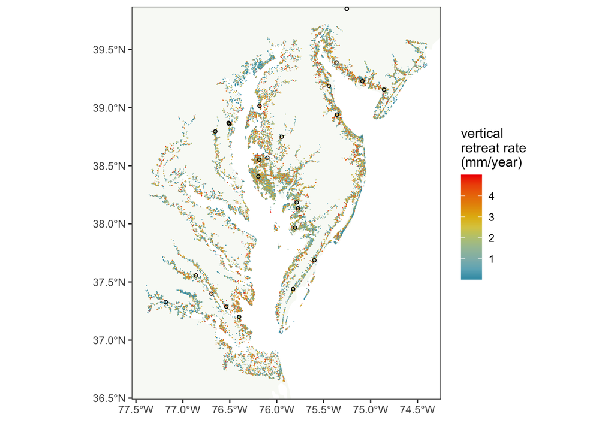

## Threshold Elevations

The second dataset is the threshold elevation defining the boundary between forest and marsh, aggregated by watershed. This is only for Maryland and Virginia, so won’t work for EXCHANGE sites in DE or NJ. https://portal.edirepository.org/nis/mapbrowse?packageid=knb-lter-vcr.343.2 File #1 contains the watershed names and threshold elevations. File #3 contains the watershed boundaries. You’ll need to identify the watershed that the EXCHANGE site is in, then find the threshold elevation for that watershed before running the regression. Its simpler than it sounds.

Projected CRS: NAD83 / UTM zone 18N = crs epsg 26918 aka should be the same as st_crs(HUC_shp)

# Analysis time!

## Elevation

```
## Correlation computed with
## • Method: 'pearson'
## • Missing treated using: 'pairwise.complete.obs'
```

```
## # A tibble: 9 × 2
##   term                            Elevation
##   <chr>                               <dbl>
## 1 bulk_density_g_cm3               -0.294
## 2 specific_conductance_us_cm        0.646
## 3 moisturecontent_perc_drywtbasis   0.549
## 4 ph                               -0.322
## 5 carbon_weight_perc                0.530
## 6 nitrogen_weight_perc              0.357
## 7 latitude                         -0.404
## 8 longitude                         0.472
## 9 elevation_m                       0.00350
```

```
##
## Call:
## lm(formula = Elevation ~ ., data = clc_data_num_2)
##
## Residuals:
##      Min       1Q   Median       3Q      Max
## -0.19706 -0.04829  0.04441  0.07097  0.14212
##
## Coefficients:
##                                   Estimate Std. Error t value Pr(>|t|)
## (Intercept)                      2.233e+01  1.036e+01   2.156    0.068 .
## bulk_density_g_cm3              -1.617e-01  2.189e-01  -0.739    0.484
## specific_conductance_us_cm      -4.525e-06  2.107e-05  -0.215    0.836
## moisturecontent_perc_drywtbasis  5.114e-04  4.047e-04   1.264    0.247
## ph                               5.327e-02  1.052e-01   0.507    0.628
## carbon_weight_perc               1.842e-02  2.738e-02   0.673    0.523
## nitrogen_weight_perc            -4.315e-01  4.095e-01  -1.054    0.327
## latitude                        -1.124e-01  8.556e-02  -1.314    0.230
## longitude                        2.311e-01  1.316e-01   1.756    0.122
## elevation_m                      4.923e-02  5.233e-02   0.941    0.378
## ---
## Signif. codes:  0 '***' 0.001 '**' 0.01 '*' 0.05 '.' 0.1 ' ' 1
##
## Residual standard error: 0.1536 on 7 degrees of freedom
##   (1 observation deleted due to missingness)
## Multiple R-squared:  0.7107, Adjusted R-squared:  0.3387
## F-statistic: 1.911 on 9 and 7 DF,  p-value: 0.2028
```

```
## Correlation computed with
## • Method: 'spearman'
## • Missing treated using: 'pairwise.complete.obs'
```

```
## # A tibble: 9 × 2
##   term                            Elevation
##   <chr>                               <dbl>
## 1 bulk_density_g_cm3                 -0.298
## 2 specific_conductance_us_cm          0.210
## 3 moisturecontent_perc_drywtbasis     0.267
## 4 ph                                 -0.219
## 5 carbon_weight_perc                  0.345
## 6 nitrogen_weight_perc                0.279
## 7 latitude                           -0.155
## 8 longitude                           0.296
## 9 elevation_m                         0.317
```

```
##                          Variable correlation.cor     p.value
## 1      specific_conductance_us_cm       0.6455817 0.005124898
## 2 moisturecontent_perc_drywtbasis       0.5486511 0.018383577
## 3              carbon_weight_perc       0.5300481 0.028628356
## 4                       longitude       0.4721933 0.047860251
```

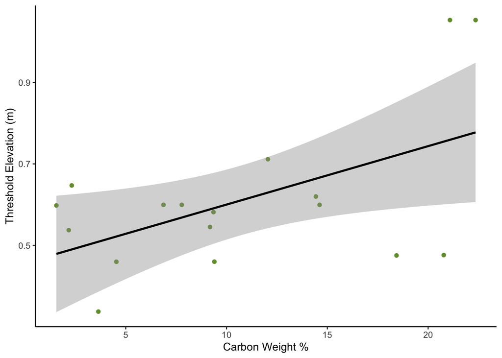